# Tarea N°1

Arqueología Cuantitativa

Esteban Arroyo y Patricio De Souza

# Tarea N° 1

## Para efectuar este trabajo, considera la BD1_Trabajos_2023 contenida en material docente, donde se especifican variables categóricas y numéricas que caracterizan un conjunto de instrumentos líticos. Utilizando RStudio, efectúe los siguientes ejercicios a partir de estos datos:

### Cargamos las librerías que vamos a usar

```r
library(readxl)
library(dplyr)
library(ggplot2)
library(psych)
library(kableExtra)
```

### Cargamos nuestra base de datos

```r
data_set <- read_excel("BD1_Trabajos_2023.xlsx", sheet="Hoja1")
```

### Vemos el tipo de variables que tenemos en la base

```r
str(data_set)
```

```
tibble [612 x 16] (S3: tbl_df/tbl/data.frame)
 $ Sitio                   : chr [1:612] "Tu-58" "Tu-58" "Tu-58" "Tu-58" ...
 $ Capa                    : chr [1:612] "1" "2" "3" "1" ...
 $ Cuadrícula              : chr [1:612] "A5/SW" "A6/SW" "A5/SW" "A5/SW" ...
 $ Nivel                   : chr [1:612] "3" "2" "13-17" "5" ...
 $ Largo morfológico       : chr [1:612] "11.41" "12.15" "13.08" "13.1" ...
 $ Conservación            : chr [1:612] "Completa" "Completa" "Completa" "Completa" ...
 $ Fragmentación           : chr [1:612] "Completa" "Completa" "Completa" "Completa" ...
 $ Mat.prima               : chr [1:612] "Silíceas" "Silíceas" "Silíceas" "Silíceas" ...
 $ F. Base                 : chr [1:612] "Lasca" "Lámina" "Lasca" "Frag.bifaz" ...
 $ Corteza                 : chr [1:612] "0%" "0%" "0%" "0%" ...
 $ T. Talón                : chr [1:612] "ND" "ND" "Facetado" "nd" ...
 $ Tecnología              : chr [1:612] "Monofacial marginal" "Bifacial extendido" "Bifacial extendido" "nd" ...
 $ Extensión borde activo  : chr [1:612] "Largo" "Corto" "Largo" "nd" ...
 $ Simetría del borde      : chr [1:612] "Asimétrico" "Simétrico" "Simétrico" "nd" ...
 $ Categoría morfofuncional: chr [1:612] "Perforadores" "Perforadores" "Perforadores" "Núcleos" ...
 $ Tipos                   : chr [1:612] NA NA NA "Bipolar" ...
```

### Observamos que todas las variables estan consideradas como “chr” (character), es decir, en formato texto, lo cual no corresponde porque las variables numericas deberían ser “num” o “int” y las variables categóricas deberían ser “factor”. Tambien observamos que tenemos datos “nd” y “vacíos”.

### Se realizarán los cambios según las variables seleccionadas para las distintas preguntas.

## 1. Construya una tabla de contingencia y un gráfico que permita examinar la relación entre materia prima y otra variable nominal a elección. Defina qué patrones o tendencias se pueden desprender.

### Creo una nueva base solo con las columnas que necesito y elimino los “nd” y “vacios”

```r
data_set_mod1 <- select(data_set, c("Mat.prima", `Simetría del borde`))
```

### Ahora contamos cuantos valores son iguales a “nd”

```r
sum (data_set_mod1$`Simetría del borde` == "nd")
```

```
[1] 185
```

### Ahora vamos a imputar valores “nd” de la columna Simetría del borde como NA (“vacios”)

```r
data_set_mod1$`Simetría del borde`[data_set_mod1$`Simetría del borde`=="nd"] <- NA
```

### Elimino las filas que tienen NA

```r
data_set_mod1 <- na.omit(data_set_mod1)
```

### Convierto en factor a las variables Mat.prima y Simetría del borde

```r
data_set_mod1$Mat.prima <- factor(data_set_mod1$Mat.prima)
data_set_mod1$`Simetría del borde` <- factor(data_set_mod1$`Simetría del borde`)
```

### Realizo la tabla de contingencia

```r
addmargins(table(data_set_mod1$Mat.prima, data_set_mod1$`Simetría del borde`), margin=1) %>% kbl() %>% kable_classic_2(full_width = FALSE, position = "center")
```

|  | Asimétrico | Simétrico |
| --- | --- | --- |
| Basalto | 25 | 55 |
| Obsidiana | 13 | 38 |
| Otras | 3 | 2 |
| Silíceas | 38 | 95 |
| Toba | 93 | 65 |
| Sum | 172 | 255 |

### Convertimos nuestra tabla de contingencia en porporciones según columna

```r
addmargins(prop.table(table(data_set_mod1$Mat.prima, data_set_mod1$`Simetría del borde`), margin=2), margin=1) %>% kbl() %>% kable_classic_2(full_width = FALSE, position = "center")
```

|  | Asimétrico | Simétrico |
| --- | --- | --- |
| Basalto | 0.1453488 | 0.2156863 |
| Obsidiana | 0.0755814 | 0.1490196 |
| Otras | 0.0174419 | 0.0078431 |
| Silíceas | 0.2209302 | 0.3725490 |
| Toba | 0.5406977 | 0.2549020 |
| Sum | 1.0000000 | 1.0000000 |

### Ahora hacemos los gráficos

### Con frecuencias absolutas

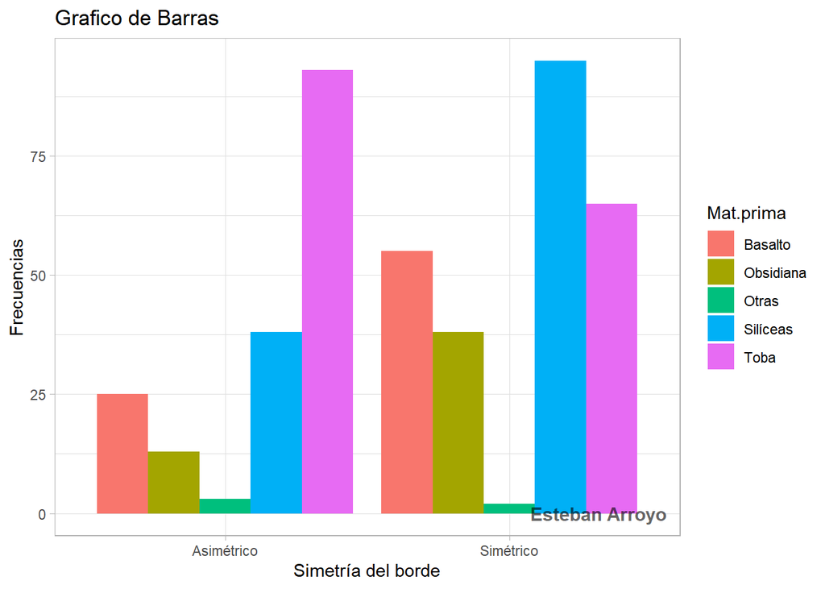

```r
ggplot(data = data_set_mod1) + geom_bar(aes(x = `Simetría del borde`, fill=Mat.prima), position = 'dodge') + theme_light() + ylab("Frecuencias") + annotate("text", x=Inf,y=-Inf, label="Esteban Arroyo",hjust=1.1,vjust=-1.1,col="black",cex=4,fontface = "bold", alpha = 0.6)+ggtitle('Grafico de Barras')
```

### Con porcentajes

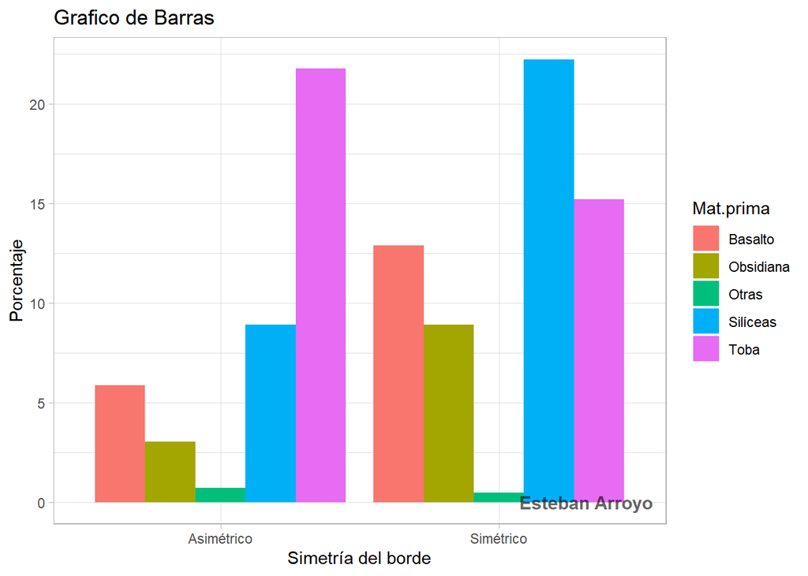

```r
ggplot(data = data_set_mod1) + geom_bar(aes(x = `Simetría del borde`, y = ((..count..)/sum(..count..))*100,  fill=Mat.prima), position = 'dodge') + theme_light() + ylab("Porcentaje") + annotate("text",x=Inf, y=-Inf, label="Esteban Arroyo", hjust=1.1,vjust=-1.1, col="black",cex=4,fontface = "bold", alpha = 0.6)+ggtitle('Grafico de Barras')
```

## 2. Construya una tabla de contingencia y un gráfico que permita examinar los cambios a lo largo de la secuencia del sitio (según las capas definidas) de alguna variable nominal a elección. Defina qué patrones o tendencias se pueden desprender.

### Creo una nueva base solo con las columnas que necesito

```r
data_set_mod2 <- select(data_set, c("Mat.prima", "Capa"))
#hacemos una primera tabla para ver lo que tenemos
table(data_set_mod2$Capa, data_set_mod2$Mat.prima) %>% kbl() %>% kable_classic_2(full_width = FALSE, position = "center")
```

|  | Basalto | Granito | Obsidiana | Otras | Silíceas | Toba |
| --- | --- | --- | --- | --- | --- | --- |
| 0 | 10 | 4 | 9 | 0 | 11 | 26 |
| 1 | 6 | 1 | 16 | 0 | 17 | 11 |
| 2 | 9 | 1 | 8 | 1 | 15 | 21 |
| 3 | 74 | 5 | 63 | 4 | 104 | 97 |
| 4 | 14 | 1 | 10 | 2 | 24 | 26 |
| lp | 5 | 1 | 2 | 1 | 6 | 7 |

### Eliminamos la categoría “lp” de “Capa”, ya que no tiene “nivel asignado”

```r
data_set_mod2 <- data_set_mod2[data_set_mod2$Capa != "lp", ]
data_set_mod2$Capa <- factor(data_set_mod2$Capa)  #convertimos a factor la variable Capa
#Realizamos la tabla
addmargins(table(data_set_mod2$Capa, data_set_mod2$Mat.prima), margin=2) %>% kbl() %>% kable_classic_2(full_width = FALSE, position = "center")
```

|  | Basalto | Granito | Obsidiana | Otras | Silíceas | Toba | Sum |
| --- | --- | --- | --- | --- | --- | --- | --- |
| 0 | 10 | 4 | 9 | 0 | 11 | 26 | 60 |
| 1 | 6 | 1 | 16 | 0 | 17 | 11 | 51 |
| 2 | 9 | 1 | 8 | 1 | 15 | 21 | 55 |
| 3 | 74 | 5 | 63 | 4 | 104 | 97 | 347 |
| 4 | 14 | 1 | 10 | 2 | 24 | 26 | 77 |

### Ahora realizamos la tabla de proporciones en función de las filas

```r
addmargins(prop.table(table(data_set_mod2$Capa, data_set_mod2$Mat.prima), margin=1), margin=2) %>% kbl() %>% kable_classic_2(full_width = FALSE, position = "center")
```

|  | Basalto | Granito | Obsidiana | Otras | Silíceas | Toba | Sum |
| --- | --- | --- | --- | --- | --- | --- | --- |
| 0 | 0.1666667 | 0.0666667 | 0.1500000 | 0.0000000 | 0.1833333 | 0.4333333 | 1 |
| 1 | 0.1176471 | 0.0196078 | 0.3137255 | 0.0000000 | 0.3333333 | 0.2156863 | 1 |
| 2 | 0.1636364 | 0.0181818 | 0.1454545 | 0.0181818 | 0.2727273 | 0.3818182 | 1 |
| 3 | 0.2132565 | 0.0144092 | 0.1815562 | 0.0115274 | 0.2997118 | 0.2795389 | 1 |
| 4 | 0.1818182 | 0.0129870 | 0.1298701 | 0.0259740 | 0.3116883 | 0.3376623 | 1 |

### Ahora Hacemos el gráfico

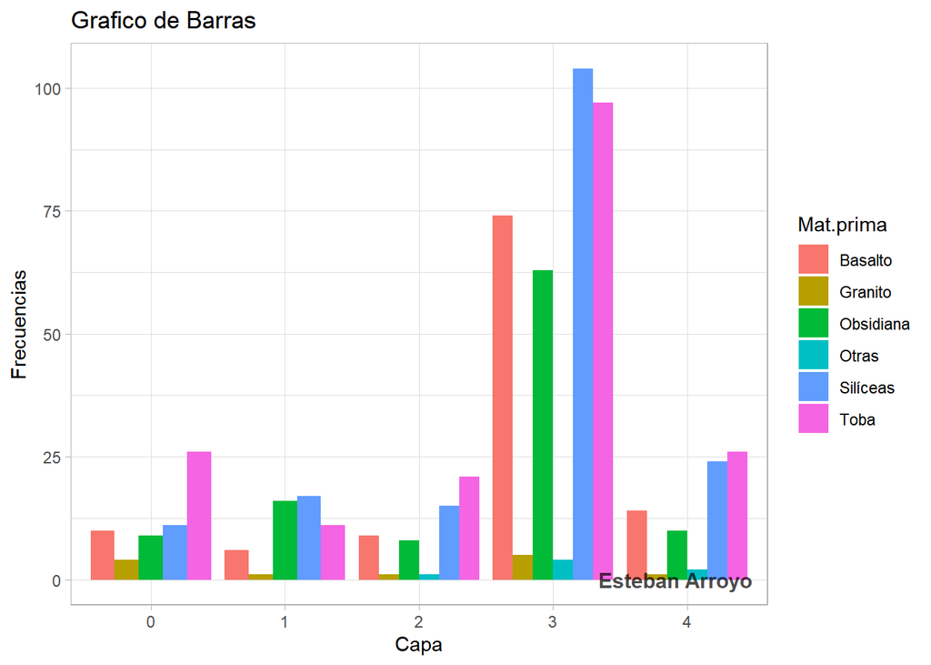

```r
ggplot(data = data_set_mod2) + geom_bar(aes(x = Capa, fill=Mat.prima), position = 'dodge') + theme_light() + ylab("Frecuencias") + annotate("text", x=Inf,y=-Inf, label="Esteban Arroyo",hjust=1.1,vjust=-1.1,col="black",cex=4,fontface = "bold", alpha = 0.7)+ggtitle("Grafico de Barras")
```

## 3. Elija tres categorías morfofuncionales de las especificadas en la base de datos. Para aquellas seleccionadas, compare los largos morfológicos, efectuando lo siguiente:

### Hacemos un subset con las categorias seleccionadas

```r
data_set_mod3 <- subset(data_set, `Categoría morfofuncional` == "Cuchillos" | `Categoría morfofuncional` == "Núcleos" | `Categoría morfofuncional` == "Perforadores", select=c(`Categoría morfofuncional`,`Largo morfológico`))
```

### imputar valores “nd” de la columna Largo morfológico

```r
data_set_mod3$`Largo morfológico`[data_set_mod3$`Largo morfológico`=="nd"] <- NA
```

### Convertir la columna Largo morfológico en numerica para hacer calculos descriptivos

```r
data_set_mod3$`Largo morfológico` <- as.numeric(data_set_mod3$`Largo morfológico`)
```

### Contamos y eliminamos los NA (“vacíos”) de la base nueva

```r
sum(is.na(data_set_mod3))                #Aquí contamos cuantos valores vaciones existen
```

```
[1] 51
```

```r
data_set_mod3 <- na.omit(data_set_mod3)  #Aquí los eliminamos
sum(is.na(data_set_mod3))                #Volvemos a contar para verificar
```

```
[1] 0
```

### Convertimos Categoría morfofuncional en factor

```r
data_set_mod3$`Categoría morfofuncional` <- factor(data_set_mod3$`Categoría morfofuncional`)
```

## a) Calcule y tabule los estadísticos descriptivos de medidas centrales y de dispersión vistos en clases

### Para hacer las estadísticas descriptivas usaremos la función describeBy del paquete “psych”

```r
describeBy(data_set_mod3$`Largo morfológico`, group=data_set_mod3$`Categoría morfofuncional`, quant=c(.25,.75), IQR=TRUE, mat=TRUE) %>% kbl() %>% kable_classic_2(full_width = F, position = "center")
```

|  | item | group1 | vars | n | mean | sd | median | trimmed | mad | min | max | range | skew | kurtosis | se | IQR | Q0.25 | Q0.75 |
| --- | --- | --- | --- | --- | --- | --- | --- | --- | --- | --- | --- | --- | --- | --- | --- | --- | --- | --- |
| 11 | 1 | Cuchillos | 1 | 14 | 32.10000 | 10.529811 | 28.30 | 31.59167 | 9.043860 | 17.50 | 52.80 | 35.30 | 0.4784015 | -1.107522 | 2.814210 | 15.475 | 23.775 | 39.25 |
| 12 | 2 | Núcleos | 1 | 41 | 33.80732 | 24.706987 | 23.10 | 28.66667 | 7.264740 | 13.10 | 106.80 | 93.70 | 1.6265815 | 1.421944 | 3.858583 | 14.200 | 19.000 | 33.20 |
| 13 | 3 | Perforadores | 1 | 59 | 25.57153 | 9.768903 | 23.11 | 24.44184 | 7.101654 | 11.41 | 56.39 | 44.98 | 1.2023700 | 1.164546 | 1.271803 | 10.275 | 19.425 | 29.70 |

## b) Construya boxplots (caja y bigote) para permitan representar y poner en comparación las distribuciones correspondientes.

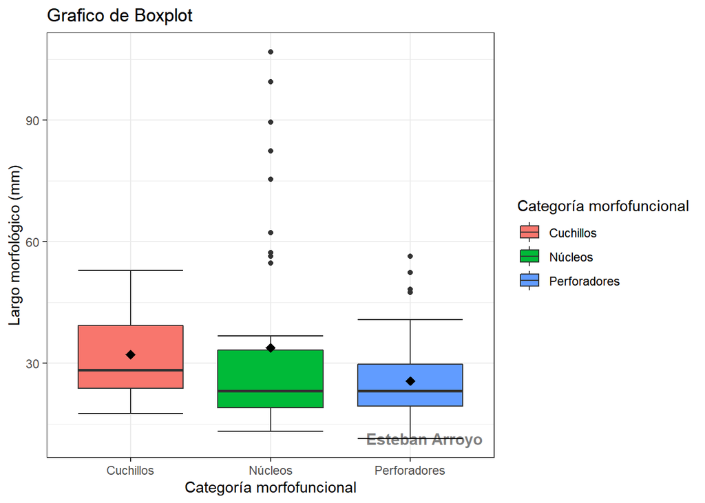

```r
ggplot(data_set_mod3,aes(x=`Categoría morfofuncional`,y=`Largo morfológico`)) + stat_boxplot(geom="errorbar") + geom_boxplot(aes(fill=`Categoría morfofuncional`)) + stat_summary(fun=mean,geom="point",shape=18,size=3,color="black") + theme_bw() +  ylab("Largo morfológico (mm)") + annotate("text",x=Inf,y=-Inf,label="Esteban Arroyo",hjust=1.1,vjust=-1.1,col="black",cex=4,fontface = "bold", alpha = 0.5)+ggtitle("Grafico de Boxplot")
```

### Hacemos un histograma para revisar la forma de su distribución

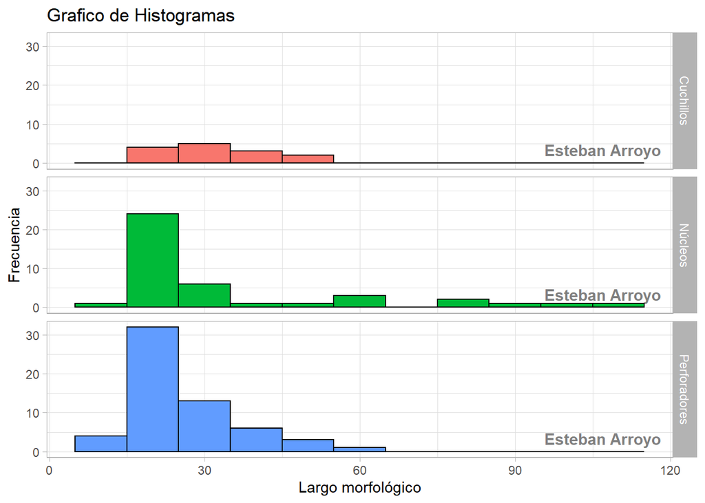

```r
ggplot(data_set_mod3,aes(x=`Largo morfológico`)) + geom_histogram(binwidth = 10, color="black", aes(fill=`Categoría morfofuncional`), show.legend = FALSE) + facet_grid("`Categoría morfofuncional`")+ theme_light() + ylab("Frecuencia") + annotate("text",x=Inf,y=-Inf,label="Esteban Arroyo",hjust=1.1,vjust=-1.1,col="black",cex=4,fontface = "bold", alpha = 0.5)+ggtitle("Grafico de Histogramas")
```